# BANA 288 Final Project E-Commerce Shipping Predection

## Project Overview

Our dataset is from an international e-commerce company about their customer. It has 10999 observations of 12 variables. Our target variable is whether a piece of goods is delivered on time or not.  
During COVID, business are forced to shut doors, so many customers start to shop online, these exponential increase placed a huge strain on shipping networks and increased competition among e-commerce sellers, whoever can beat the door and provide ensured on-time deliveries can stand out in this competition and hold a space in the market. We want use machine learning techniques to help them study their customers and build an accurate classifier to predict whether goods can arrive on time or not. From doing so, we hope to pinpoint areas where company can improve their services and stand out in the competition.

## Pre-processing

```r
# options(stringsAsFactors = TRUE)
data = read.csv('Train.csv')

# Check for missing values
options(repr.plot.width = 8, repr.plot.height = 3)
plot_missing(data)

# There are 0 missing rows moving forward.
dat = na.omit(data)
dim(data)
```

```
## [1] 10999    12
```

```r
# getting a general sense of the data
describe(data)
```

```
## data
##
##  12  Variables      10999  Observations
## --------------------------------------------------------------------------------
## ID
##        n  missing distinct     Info     Mean      Gmd      .05      .10
##    10999        0    10999        1     5500     3667    550.9   1100.8
##      .25      .50      .75      .90      .95
##   2750.5   5500.0   8249.5   9899.2  10449.1
##
## lowest :     1     2     3     4     5, highest: 10995 10996 10997 10998 10999
## --------------------------------------------------------------------------------
## Warehouse_block
##        n  missing distinct
##    10999        0        5
##
## lowest : A B C D F, highest: A B C D F
##
## Value          A     B     C     D     F
## Frequency   1833  1833  1833  1834  3666
## Proportion 0.167 0.167 0.167 0.167 0.333
## --------------------------------------------------------------------------------
## Mode_of_Shipment
##        n  missing distinct
##    10999        0        3
##
## Value      Flight   Road   Ship
## Frequency    1777   1760   7462
## Proportion  0.162  0.160  0.678
## --------------------------------------------------------------------------------
## Customer_care_calls
##        n  missing distinct     Info     Mean      Gmd
##    10999        0        6    0.931    4.054    1.251
##
## lowest : 2 3 4 5 6, highest: 3 4 5 6 7
##
## Value          2     3     4     5     6     7
## Frequency    638  3217  3557  2328  1013   246
## Proportion 0.058 0.292 0.323 0.212 0.092 0.022
## --------------------------------------------------------------------------------
```

[output cut: 50 more lines]

```
## lowest :  1  2  3  4  5, highest: 61 62 63 64 65
## --------------------------------------------------------------------------------
## Weight_in_gms
##        n  missing distinct     Info     Mean      Gmd      .05      .10
##    10999        0     4034        1     3634     1857     1163     1327
##      .25      .50      .75      .90      .95
##     1840     4149     5050     5632     5807
##
## lowest : 1001 1002 1003 1004 1005, highest: 7401 7588 7640 7684 7846
## --------------------------------------------------------------------------------
## Reached.on.Time_Y.N
##        n  missing distinct     Info      Sum     Mean      Gmd
##    10999        0        2    0.722     6563   0.5967   0.4813
##
## --------------------------------------------------------------------------------
```

```r
# Encode variables
dat = data %>%
  mutate(Warehouse_block = as.factor(Warehouse_block),
         Mode_of_Shipment = as.factor(Mode_of_Shipment),
         Product_importance = as.factor(Product_importance),
         Gender = as.factor(Gender))
# check
str(dat)
```

```
## 'data.frame':    10999 obs. of  12 variables:
##  $ ID                 : int  1 2 3 4 5 6 7 8 9 10 ...
##  $ Warehouse_block    : Factor w/ 5 levels "A","B","C","D",..: 4 5 1 2 3 5 4 5 1 2 ...
##  $ Mode_of_Shipment   : Factor w/ 3 levels "Flight","Road",..: 1 1 1 1 1 1 1 1 1 1 ...
##  $ Customer_care_calls: int  4 4 2 3 2 3 3 4 3 3 ...
##  $ Customer_rating    : int  2 5 2 3 2 1 4 1 4 2 ...
##  $ Cost_of_the_Product: int  177 216 183 176 184 162 250 233 150 164 ...
##  $ Prior_purchases    : int  3 2 4 4 3 3 3 2 3 3 ...
##  $ Product_importance : Factor w/ 3 levels "high","low","medium": 2 2 2 3 3 3 2 2 2 3 ...
##  $ Gender             : Factor w/ 2 levels "F","M": 1 2 2 2 1 1 1 1 1 1 ...
##  $ Discount_offered   : int  44 59 48 10 46 12 3 48 11 29 ...
##  $ Weight_in_gms      : int  1233 3088 3374 1177 2484 1417 2371 2804 1861 1187 ...
##  $ Reached.on.Time_Y.N: int  1 1 1 1 1 1 1 1 1 1 ...
```

[figure not shown]

## Correlation matrix

```r
# filter dataset for numerical variables only
dat_num <- dat %>%
    dplyr::select(-ID, -Warehouse_block, -Mode_of_Shipment, - Product_importance, - Gender)
str(dat_num)
```

```
## 'data.frame':    10999 obs. of  7 variables:
##  $ Customer_care_calls: int  4 4 2 3 2 3 3 4 3 3 ...
##  $ Customer_rating    : int  2 5 2 3 2 1 4 1 4 2 ...
##  $ Cost_of_the_Product: int  177 216 183 176 184 162 250 233 150 164 ...
##  $ Prior_purchases    : int  3 2 4 4 3 3 3 2 3 3 ...
##  $ Discount_offered   : int  44 59 48 10 46 12 3 48 11 29 ...
##  $ Weight_in_gms      : int  1233 3088 3374 1177 2484 1417 2371 2804 1861 1187 ...
##  $ Reached.on.Time_Y.N: int  1 1 1 1 1 1 1 1 1 1 ...
```

```r
# function to flatten matrix
flattenCorrMatrix = function(cormat, pmat)
{
  ut = upper.tri(cormat)
  data.frame(
    row = rownames(cormat)[row(cormat)[ut]],
    column = rownames(cormat)[col(cormat)[ut]],
    cor  =(cormat)[ut],
    p = pmat[ut]
  )
}

# Use it on our data to generate a correlation matrix with P values
res = rcorr(as.matrix(dat_num))
result = flattenCorrMatrix(res$r, res$P)

# Selects The top 3 variables with the highest absolute values of correlation
# Coefficients with "Reached.on.Time_Y.N"
result_tail = tail(result, 6)
Top_4_corr = result_tail %>%
  mutate(abs_cor = abs(cor)) %>%
  arrange(desc(abs_cor)) %>%
  top_n(n = 4)
Top_4_corr
```

```
##                   row              column         cor            p    abs_cor
## 1    Discount_offered Reached.on.Time_Y.N  0.39710847 0.000000e+00 0.39710847
## 2       Weight_in_gms Reached.on.Time_Y.N -0.26879258 0.000000e+00 0.26879258
## 3 Cost_of_the_Product Reached.on.Time_Y.N -0.07358721 1.110223e-14 0.07358721
## 4 Customer_care_calls Reached.on.Time_Y.N -0.06712586 1.827427e-12 0.06712586
```

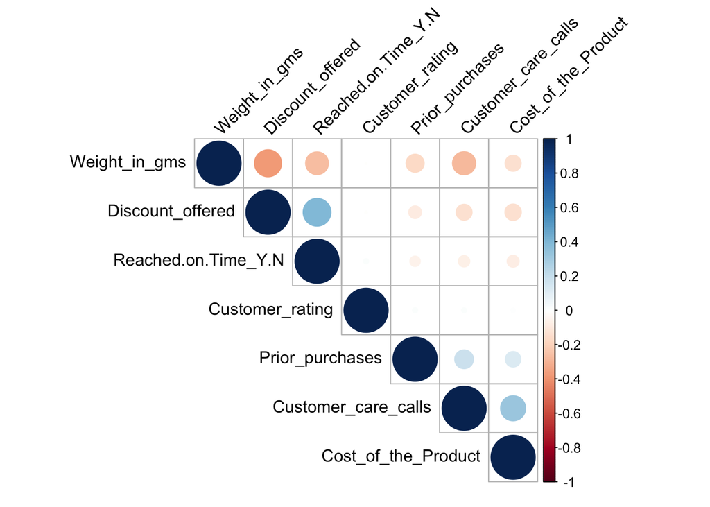

```r
# Not counting the ID, the top 3 variables are Discount_offered, Weight_in_gms & Cost_of_the_Product.
# Plot it
corrplot(cor(dat_num), type = "upper", order = "hclust", tl.col = "black", tl.srt = 45)
```

## EDA

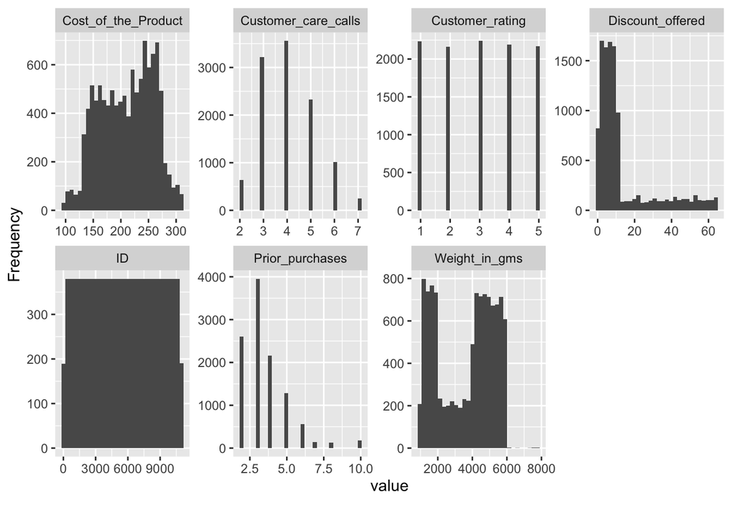

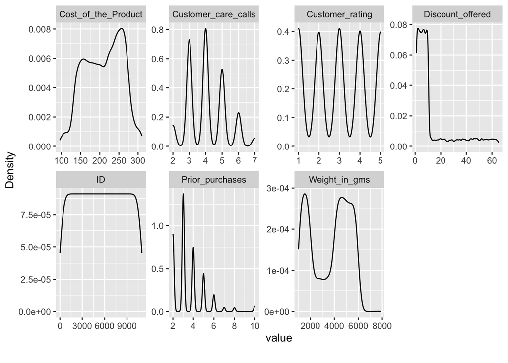

```r
# General plots
plot_histogram(dat)
plot_density(dat)
```

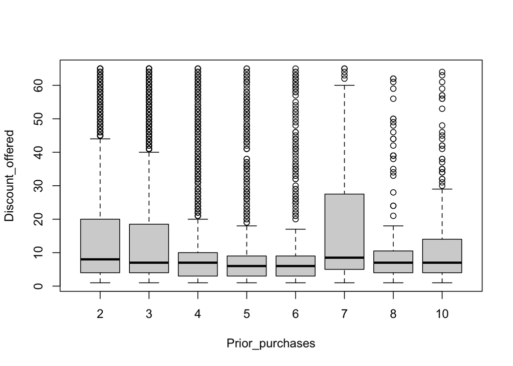

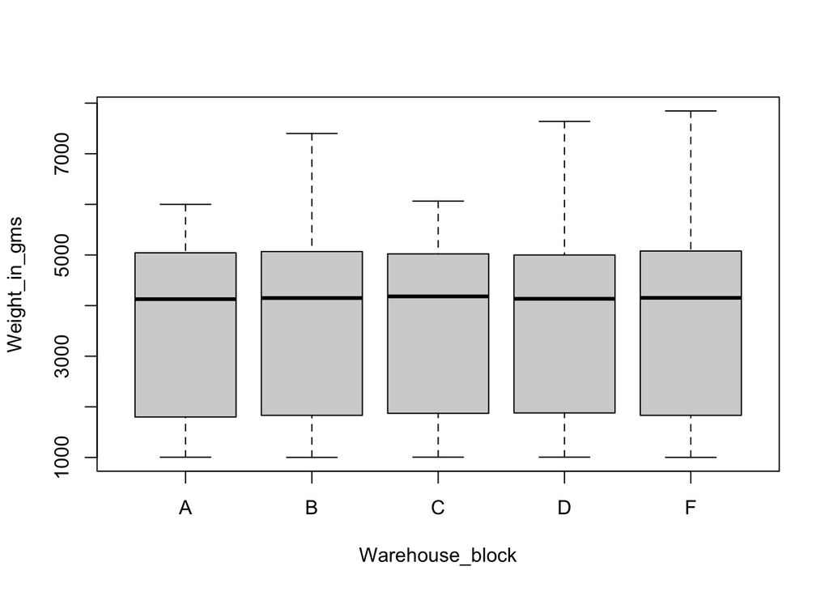

```r
# Basic boxplot
boxplot(Discount_offered  ~ Prior_purchases, data = dat)
# Discounts are given  all across, not just to orders with prior purchases.
boxplot(Weight_in_gms ~ Warehouse_block, data = dat)
```

From above boxplots, we discover that: (1) Discounts are given all across the orders, not just to orders with prior purchases. (2) Among the warehouses, there seems to be no significant characteristics in each of the warehouse blocks. Warehouse B,D and F seems to handle more variety of products as the range of product weights for them is bigger.

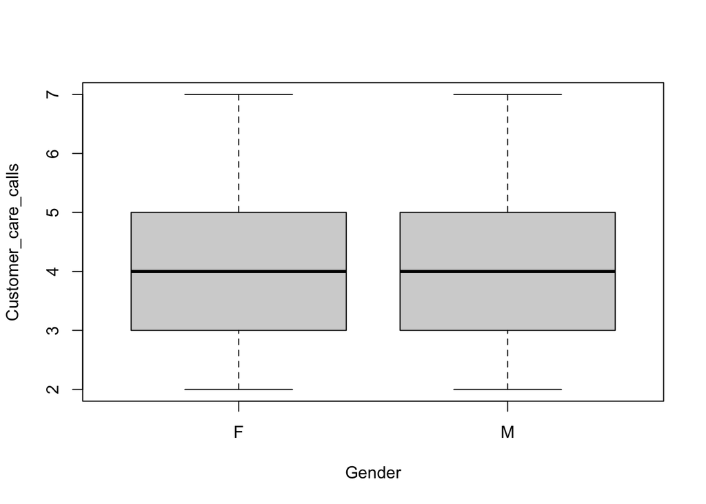

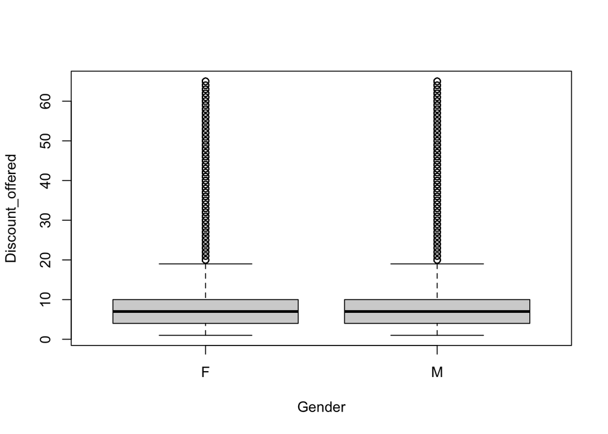

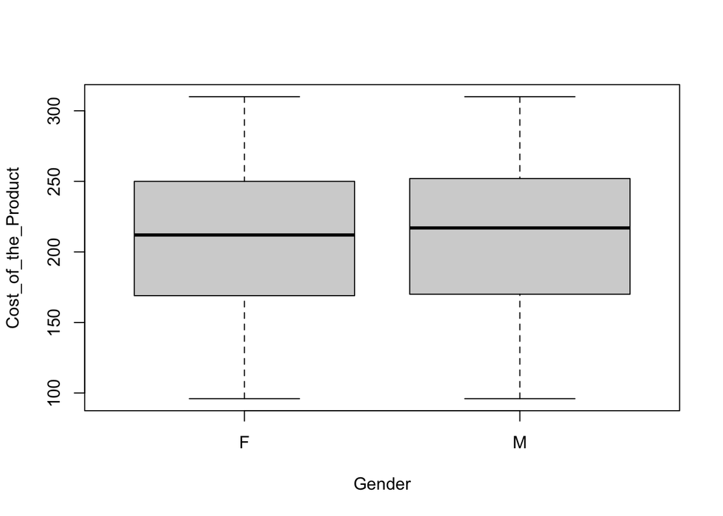

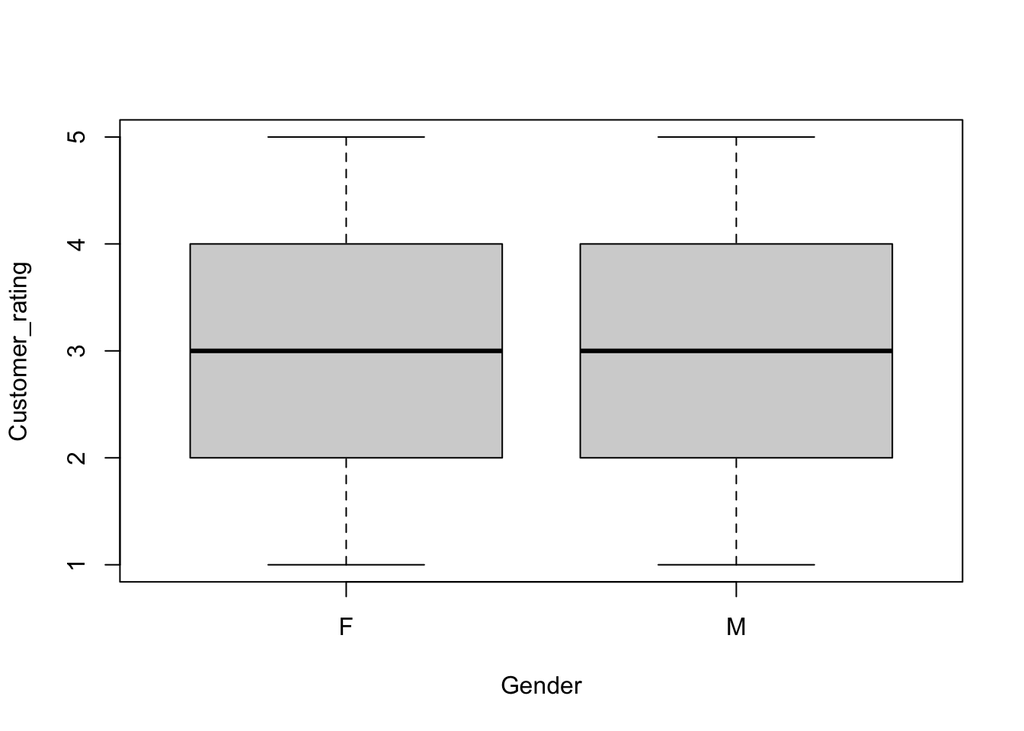

```r
# checking if gender matters
boxplot(Customer_care_calls ~ Gender, data = dat)
boxplot(Discount_offered ~ Gender, data = dat)
boxplot(Cost_of_the_Product ~ Gender, data = dat)
boxplot(Customer_rating  ~ Gender, data = dat)
```

In any of these boxplots, there are no significant difference between the male & female shippers.

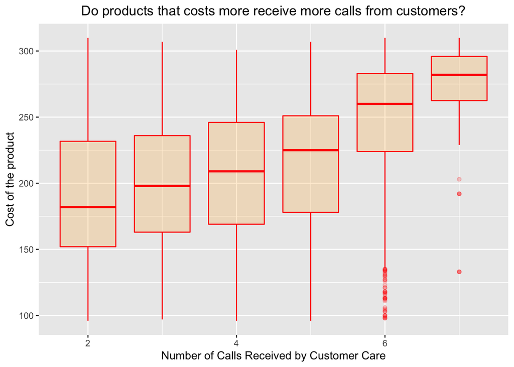

```r
# Fancy boxplot # 1
ggplot(data = dat, aes(x = Customer_care_calls , y = Cost_of_the_Product,
                       group = Customer_care_calls)) +
  geom_boxplot(color="red", fill="orange", alpha = 0.2) +
  labs(title = 'Do products that costs more receive more calls from customers?',
       y ='Cost of the product',
       x = 'Number of Calls Received by Customer Care') +
  theme(plot.title = element_text(hjust = 0.5))
```

We discovered that the more expensive a product is, the more calls received by customer care. This makes sense, the more valuable a product is, the more costs to the customers if such products getting lost, therefore they want to keep up with the shipping status tightly.

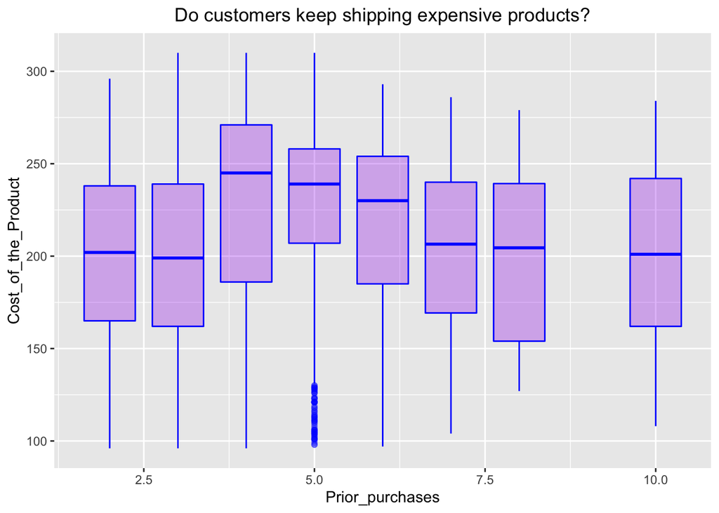

```r
# fancy boxplot # 2
# boxplot(Cost_of_the_Product  ~ Prior_purchases, data = dat)
ggplot(data = dat, aes(x = Prior_purchases , y = Cost_of_the_Product ,
                       group = Prior_purchases)) +
  geom_boxplot(color="blue", fill="purple",alpha=0.3) +
  theme(legend.position = "none") +
  labs(title = 'Do customers keep shipping expensive products?',
       y ='Cost_of_the_Product',
       x = 'Prior_purchases')  +
  theme(plot.title = element_text(hjust = 0.5))
```

```r
# Reached-on-time Focus Visuals
# Warehouses
T1 = dat %>%
  group_by(Warehouse_block) %>%
  summarise(yes_percent = percent(sum(Reached.on.Time_Y.N == 1) / n()),
            no_percent = percent(sum(Reached.on.Time_Y.N == 0) / n()))
```

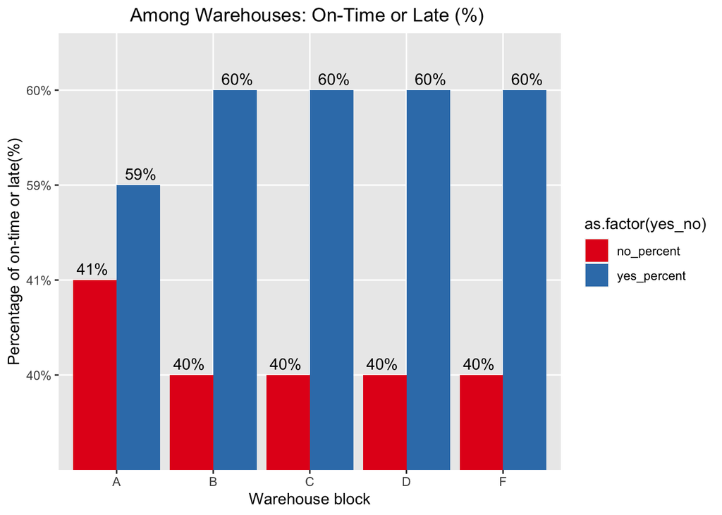

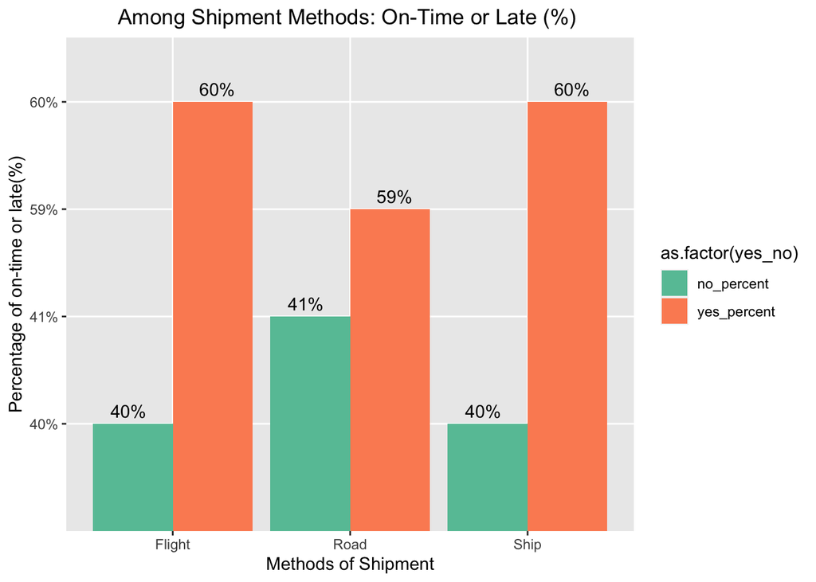

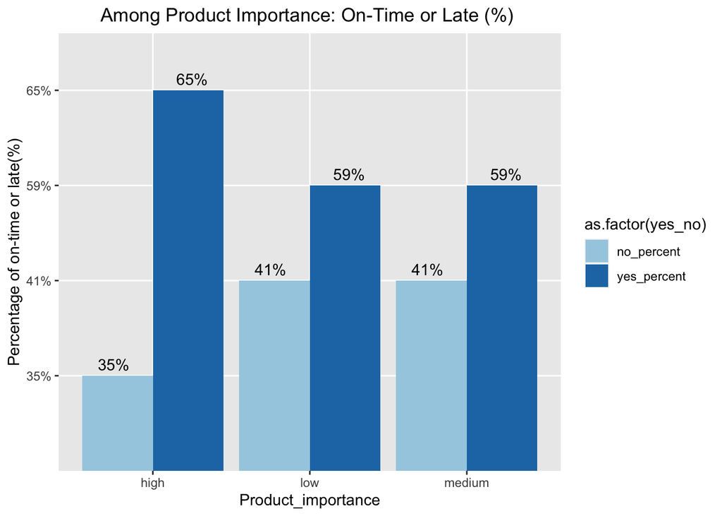

```r
T2 = gather(T1, yes_no, percent, -Warehouse_block)

ggplot(data = T2, aes(x = Warehouse_block, y = percent,
                      fill= as.factor(yes_no))) +
  geom_bar(stat='identity', position="dodge") +
  scale_fill_brewer(palette ="Set1") +
  geom_text(aes(label = percent),
            position = position_dodge(width = 1), vjust = -0.5) +
  labs(title = 'Among Warehouses: On-Time or Late (%) ',
       y ='Percentage of on-time or late(%)',
       x = 'Warehouse block') +
  theme(plot.title = element_text(hjust = 0.5))


# Method of shipment
T11 = dat %>%
  group_by(Mode_of_Shipment) %>%
  summarise(yes_percent = percent(sum(Reached.on.Time_Y.N == 1)/n()),
            no_percent = percent(sum(Reached.on.Time_Y.N == 0)/n()))
T22 = gather(T11, yes_no, percent, -Mode_of_Shipment)

ggplot(data = T22, aes(x = Mode_of_Shipment, y = percent,
                       fill= as.factor(yes_no))) +
  geom_bar(stat='identity', position="dodge") +
  scale_fill_brewer(palette ="Set2") +
  geom_text(aes(label = percent),
            position = position_dodge(width = 1), vjust = -0.5) +
  labs(title = 'Among Shipment Methods: On-Time or Late (%) ',
       y ='Percentage of on-time or late(%)',
       x = 'Methods of Shipment') +
  theme(plot.title = element_text(hjust = 0.5))



# Product Importance
T111 = dat %>%
  group_by(Product_importance) %>%
  summarise(yes_percent = percent(sum(Reached.on.Time_Y.N == 1) / n()),
            no_percent = percent(sum(Reached.on.Time_Y.N == 0) / n()))
T222 = gather(T111, yes_no, percent, -Product_importance)

ggplot(data = T222, aes(x = Product_importance, y = percent,
                        fill= as.factor(yes_no))) +
  geom_bar(stat='identity', position="dodge") +
  scale_fill_brewer(palette ="Paired") +
  geom_text(aes(label = percent),
            position = position_dodge(width = 1), vjust = -0.5) +
  labs(title = 'Among Product Importance: On-Time or Late (%) ',
       y ='Percentage of on-time or late(%)',
       x = 'Product_importance') +
  theme(plot.title = element_text(hjust = 0.5))
```

There is no significant different on arrival time ratio based on warehouse block or mode of shipment. But product importance does matter in Arrival Time Ratio. Highly important products has the Highest Arrival Time Ratio.

## Linear Regression

We would like to fit a linear regression to estimate the cost of the items we ship based on the available attributes There are a few theories we would like to test: 1. Customers who had more purchases in the past will trust the company with more valuable goods 2. The higher the review a customer gives, the more valuable the goods they trust the company to ship 3. Giving out more discounts will lead to customers ship more expensive goods 4. The heavier the goods, the more expensive it should be.

```r
# The Reached.on.Time_Y.N programmed on time shipments as 1, and late 0. We're switching them around in the column Reached.on.Time_Fixed
data$Reached.on.Time_Fixed = ifelse(data$Reached.on.Time_Y.N == 1, 0, 1)
data$Customer_rating = as.factor(data$Customer_rating)

# Simple linear regression with all variables
linear.model.full1 = lm(Cost_of_the_Product ~ . - Reached.on.Time_Y.N - ID, data = data)
summary(linear.model.full1)
```

```
##
## Call:
## lm(formula = Cost_of_the_Product ~ . - Reached.on.Time_Y.N -
##     ID, data = data)
##
## Residuals:
##      Min       1Q   Median       3Q      Max
## -140.518  -35.085    4.626   36.036  110.286
##
## Coefficients:
##                            Estimate Std. Error t value Pr(>|t|)
## (Intercept)               1.671e+02  3.539e+00  47.222  < 2e-16 ***
## Warehouse_blockB          3.686e+00  1.484e+00   2.483  0.01304 *
## Warehouse_blockC          2.367e+00  1.484e+00   1.594  0.11086
## Warehouse_blockD          2.013e+00  1.484e+00   1.356  0.17503
## Warehouse_blockF          2.341e-01  1.286e+00   0.182  0.85552
## Mode_of_ShipmentRoad      1.647e+00  1.511e+00   1.090  0.27573
## Mode_of_ShipmentShip      1.908e+00  1.186e+00   1.608  0.10780
## Customer_care_calls       1.122e+01  4.083e-01  27.488  < 2e-16 ***
## Customer_rating2          2.085e+00  1.355e+00   1.538  0.12396
## Customer_rating3         -1.325e-01  1.344e+00  -0.099  0.92147
## Customer_rating4          1.129e+00  1.351e+00   0.836  0.40343
## Customer_rating5          1.332e+00  1.354e+00   0.983  0.32543
## Prior_purchases           1.458e+00  2.916e-01   5.000 5.82e-07 ***
## Product_importancelow     3.397e+00  1.597e+00   2.127  0.03342 *
## Product_importancemedium  2.324e+00  1.603e+00   1.449  0.14727
## GenderM                   1.761e+00  8.571e-01   2.054  0.03998 *
## Discount_offered         -3.741e-01  3.130e-02 -11.951  < 2e-16 ***
## Weight_in_gms            -3.082e-03  3.129e-04  -9.851  < 2e-16 ***
## Reached.on.Time_Fixed     3.021e+00  9.657e-01   3.128  0.00176 **
## ---
## Signif. codes:  0 '***' 0.001 '**' 0.01 '*' 0.05 '.' 0.1 ' ' 1
##
## Residual standard error: 44.92 on 10980 degrees of freedom
## Multiple R-squared:  0.128,  Adjusted R-squared:  0.1266
## F-statistic: 89.54 on 18 and 10980 DF,  p-value: < 2.2e-16
```

```r
# RMSE = 44.92 and R square is 0.128

# linear regression with factorized variables
warehouse = data$Warehouse_block
temp1 = data.frame(model.matrix(~warehouse - 1))

modes = data$Mode_of_Shipment
temp2 = data.frame(model.matrix(~modes - 1))

ratings = factor(data$Customer_rating)
temp3 = data.frame(model.matrix(~ratings - 1))

importance = factor(data$Product_importance)
temp4 = data.frame(model.matrix(~importance - 1))

sex = factor(data$Gender)
temp5 = data.frame(model.matrix(~sex - 1))

# Rearrange the columns for easier reference
data2 = cbind(data[13], temp1, temp2, data[4], temp3, data[6 : 7], temp4, temp5, data[10])

linear.model.full2 = lm(Cost_of_the_Product ~ ., data = data2)
summary(linear.model.full2)
```

```
##
## Call:
## lm(formula = Cost_of_the_Product ~ ., data = data2)
##
## Residuals:
##      Min       1Q   Median       3Q      Max
## -142.119  -35.115    4.986   36.169  119.941
##
## Coefficients: (5 not defined because of singularities)
##                        Estimate Std. Error t value Pr(>|t|)
## (Intercept)           155.09828    2.31964  66.863  < 2e-16 ***
## Reached.on.Time_Fixed   1.44902    0.95658   1.515  0.12986
## warehouseA             -0.05397    1.29116  -0.042  0.96666
## warehouseB              3.58204    1.29119   2.774  0.00554 **
## warehouseC              2.18879    1.29071   1.696  0.08995 .
## warehouseD              1.89729    1.29070   1.470  0.14160
## warehouseF                   NA         NA      NA       NA
## modesFlight            -1.94119    1.19167  -1.629  0.10335
## modesRoad              -0.28991    1.19577  -0.242  0.80844
## modesShip                    NA         NA      NA       NA
## Customer_care_calls    12.55465    0.38689  32.450  < 2e-16 ***
## ratings1               -1.42019    1.35996  -1.044  0.29637
## ratings2                0.84573    1.37071   0.617  0.53725
## ratings3               -1.51614    1.35947  -1.115  0.26477
## ratings4               -0.44186    1.36684  -0.323  0.74650
## ratings5                     NA         NA      NA       NA
## Prior_purchases         1.97193    0.28813   6.844 8.11e-12 ***
## importancehigh         -3.28391    1.60747  -2.043  0.04109 *
## importancelow           1.70802    0.90275   1.892  0.05852 .
## importancemedium             NA         NA      NA       NA
## sexF                   -1.76554    0.86086  -2.051  0.04030 *
## sexM                         NA         NA      NA       NA
## Discount_offered       -0.25895    0.02916  -8.879  < 2e-16 ***
## ---
## Signif. codes:  0 '***' 0.001 '**' 0.01 '*' 0.05 '.' 0.1 ' ' 1
##
## Residual standard error: 45.11 on 10981 degrees of freedom
## Multiple R-squared:  0.1203, Adjusted R-squared:  0.1189
## F-statistic: 88.32 on 17 and 10981 DF,  p-value: < 2.2e-16
```

For first linear regression model without factorization: RMSE = 44.92 and R square is 0.128 For the second linear regression model with factored variables: RMSE = 45.11 and R square is 0.1203. The two models don’t differ much in either RMSE or R Square values.

At alpha = 0.05, with linear.model.full1, we can see from the result that the significant variables are Warehouse_blockB, Customer_care_calls, Prior_purchases, Product_importancelow, Discount_offered, GenderM, Weight_in_gms and Reached.on.Time_Fixed The R-squared is 0.1277, which is quite low. It indicates the variables selected only contributes to 12.77% of the variations in our target variable cost of the product, indicating a poorly fitted model.

The results from linear regression also match in what we discovered in EDA: that Customer_care_calls and cost of the product are positively correlated. The more valuable their goods are, more calls are received from the customer service regarding that product.

### Find the best combination of attributes

```r
data3 = cbind(data[13], data[2 : 11])
summary(regsubsets(Cost_of_the_Product ~ ., data = data3, nbest = 1))
```

```
## Subset selection object
## Call: regsubsets.formula(Cost_of_the_Product ~ ., data = data3, nbest = 1)
## 18 Variables  (and intercept)
##                          Forced in Forced out
## Reached.on.Time_Fixed        FALSE      FALSE
## Warehouse_blockB             FALSE      FALSE
## Warehouse_blockC             FALSE      FALSE
## Warehouse_blockD             FALSE      FALSE
## Warehouse_blockF             FALSE      FALSE
## Mode_of_ShipmentRoad         FALSE      FALSE
## Mode_of_ShipmentShip         FALSE      FALSE
## Customer_care_calls          FALSE      FALSE
## Customer_rating2             FALSE      FALSE
## Customer_rating3             FALSE      FALSE
## Customer_rating4             FALSE      FALSE
## Customer_rating5             FALSE      FALSE
## Prior_purchases              FALSE      FALSE
## Product_importancelow        FALSE      FALSE
## Product_importancemedium     FALSE      FALSE
## GenderM                      FALSE      FALSE
## Discount_offered             FALSE      FALSE
## Weight_in_gms                FALSE      FALSE
## 1 subsets of each size up to 8
## Selection Algorithm: exhaustive
##          Reached.on.Time_Fixed Warehouse_blockB Warehouse_blockC
## 1  ( 1 ) " "                   " "              " "
## 2  ( 1 ) " "                   " "              " "
## 3  ( 1 ) " "                   " "              " "
## 4  ( 1 ) " "                   " "              " "
## 5  ( 1 ) "*"                   " "              " "
## 6  ( 1 ) "*"                   "*"              " "
## 7  ( 1 ) "*"                   "*"              " "
## 8  ( 1 ) "*"                   "*"              " "
##          Warehouse_blockD Warehouse_blockF Mode_of_ShipmentRoad
## 1  ( 1 ) " "              " "              " "
## 2  ( 1 ) " "              " "              " "
## 3  ( 1 ) " "              " "              " "
## 4  ( 1 ) " "              " "              " "
## 5  ( 1 ) " "              " "              " "
## 6  ( 1 ) " "              " "              " "
```

[output cut: 23 more lines]

```
## 3  ( 1 ) " "                   " "                      " "
## 4  ( 1 ) " "                   " "                      " "
## 5  ( 1 ) " "                   " "                      " "
## 6  ( 1 ) " "                   " "                      " "
## 7  ( 1 ) " "                   " "                      "*"
## 8  ( 1 ) "*"                   " "                      "*"
##          Discount_offered Weight_in_gms
## 1  ( 1 ) " "              " "
## 2  ( 1 ) "*"              " "
## 3  ( 1 ) "*"              "*"
## 4  ( 1 ) "*"              "*"
## 5  ( 1 ) "*"              "*"
## 6  ( 1 ) "*"              "*"
## 7  ( 1 ) "*"              "*"
## 8  ( 1 ) "*"              "*"
```

Again, the 8 optimal variables are Customer_care_calls, Discount_offered, Weight_in_gms, Prior_purchases, Reached.on.Time_Fixed, Warehouse_blockB, GenderM, Product_importancelow - same as the significant variables we observed in the linear regression model.

### Built linear regression model with best sets of features

```r
#Linear regression with all significant variables
reg.2 = lm(Cost_of_the_Product ~ Warehouse_block + Customer_care_calls + Prior_purchases + Product_importance + Discount_offered + Gender
            + Weight_in_gms+ + Reached.on.Time_Fixed, data = data)
summary.reg.2 = summary(reg.2)
summary.reg.2
```

```
##
## Call:
## lm(formula = Cost_of_the_Product ~ Warehouse_block + Customer_care_calls +
##     Prior_purchases + Product_importance + Discount_offered +
##     Gender + Weight_in_gms + +Reached.on.Time_Fixed, data = data)
##
## Residuals:
##      Min       1Q   Median       3Q      Max
## -139.675  -35.120    4.533   35.731  109.914
##
## Coefficients:
##                            Estimate Std. Error t value Pr(>|t|)
## (Intercept)               1.696e+02  3.293e+00  51.500  < 2e-16 ***
## Warehouse_blockB          3.683e+00  1.484e+00   2.482  0.01310 *
## Warehouse_blockC          2.353e+00  1.484e+00   1.586  0.11287
## Warehouse_blockD          1.982e+00  1.484e+00   1.336  0.18159
## Warehouse_blockF          2.180e-01  1.285e+00   0.170  0.86533
## Customer_care_calls       1.121e+01  4.081e-01  27.466  < 2e-16 ***
## Prior_purchases           1.461e+00  2.915e-01   5.010 5.53e-07 ***
## Product_importancelow     3.384e+00  1.597e+00   2.119  0.03410 *
## Product_importancemedium  2.312e+00  1.603e+00   1.442  0.14930
## Discount_offered         -3.732e-01  3.130e-02 -11.926  < 2e-16 ***
## GenderM                   1.766e+00  8.569e-01   2.061  0.03937 *
## Weight_in_gms            -3.090e-03  3.128e-04  -9.878  < 2e-16 ***
## Reached.on.Time_Fixed     3.052e+00  9.654e-01   3.161  0.00158 **
## ---
## Signif. codes:  0 '***' 0.001 '**' 0.01 '*' 0.05 '.' 0.1 ' ' 1
##
## Residual standard error: 44.92 on 10986 degrees of freedom
## Multiple R-squared:  0.1275, Adjusted R-squared:  0.1265
## F-statistic: 133.8 on 12 and 10986 DF,  p-value: < 2.2e-16
```

With our best set of 8 features, we now run linear regression again. The results we obtained are: RMSE is 44.92 and R square is 0.1275.

### ANOVA Test for effectiveness of the reduced model

```r
anova(reg.2, linear.model.full2)
```

```
## Analysis of Variance Table
##
## Model 1: Cost_of_the_Product ~ Warehouse_block + Customer_care_calls +
##     Prior_purchases + Product_importance + Discount_offered +
##     Gender + Weight_in_gms + +Reached.on.Time_Fixed
## Model 2: Cost_of_the_Product ~ Reached.on.Time_Fixed + warehouseA + warehouseB +
##     warehouseC + warehouseD + warehouseF + modesFlight + modesRoad +
##     modesShip + Customer_care_calls + ratings1 + ratings2 + ratings3 +
##     ratings4 + ratings5 + Prior_purchases + importancehigh +
##     importancelow + importancemedium + sexF + sexM + Discount_offered
##   Res.Df      RSS Df Sum of Sq F Pr(>F)
## 1  10986 22167197
## 2  10981 22350187  5   -182989
```

### Training & testing in linear regression

```r
# Divide the model into train/test sets and test for accuracy/RMSE
set.seed(246810)
train = sample(nrow(data), nrow(data) / 2)
data.train = data[train,]
data.test = data[-train,]
# Running regression model on the train set
reg.train = lm(Cost_of_the_Product ~ . - Reached.on.Time_Y.N - ID, data = data.train)
summary(reg.train)
```

```
##
## Call:
## lm(formula = Cost_of_the_Product ~ . - Reached.on.Time_Y.N -
##     ID, data = data.train)
##
## Residuals:
##      Min       1Q   Median       3Q      Max
## -131.722  -35.025    5.272   36.403  108.756
##
## Coefficients:
##                            Estimate Std. Error t value Pr(>|t|)
## (Intercept)              168.431322   5.020968  33.546  < 2e-16 ***
## Warehouse_blockB           4.110517   2.089264   1.967  0.04918 *
## Warehouse_blockC           2.304014   2.087247   1.104  0.26971
## Warehouse_blockD           4.277358   2.111517   2.026  0.04284 *
## Warehouse_blockF          -0.269957   1.829908  -0.148  0.88272
## Mode_of_ShipmentRoad       3.389549   2.132434   1.590  0.11200
## Mode_of_ShipmentShip       2.457934   1.666387   1.475  0.14027
## Customer_care_calls       10.536612   0.576827  18.266  < 2e-16 ***
## Customer_rating2           1.946781   1.912233   1.018  0.30869
## Customer_rating3           0.775578   1.890682   0.410  0.68167
## Customer_rating4           3.418392   1.905282   1.794  0.07284 .
## Customer_rating5           4.593219   1.943147   2.364  0.01812 *
## Prior_purchases            1.333975   0.414219   3.220  0.00129 **
## Product_importancelow      5.379748   2.226124   2.417  0.01570 *
## Product_importancemedium   4.724823   2.235910   2.113  0.03463 *
## GenderM                    2.128582   1.214213   1.753  0.07965 .
## Discount_offered          -0.422507   0.044230  -9.553  < 2e-16 ***
## Weight_in_gms             -0.003490   0.000445  -7.842 5.28e-15 ***
## Reached.on.Time_Fixed      3.409259   1.367734   2.493  0.01271 *
## ---
## Signif. codes:  0 '***' 0.001 '**' 0.01 '*' 0.05 '.' 0.1 ' ' 1
##
## Residual standard error: 44.96 on 5480 degrees of freedom
## Multiple R-squared:  0.1269, Adjusted R-squared:  0.124
## F-statistic: 44.25 on 18 and 5480 DF,  p-value: < 2.2e-16
```

```r
# Adjusted R-squared: 0.124
anova(reg.train)
```

```
## Analysis of Variance Table
##
## Response: Cost_of_the_Product
##                         Df   Sum Sq Mean Sq  F value    Pr(>F)
## Warehouse_block          4    19464    4866   2.4072  0.047295 *
## Mode_of_Shipment         2     3408    1704   0.8430  0.430469
## Customer_care_calls      1  1223431 1223431 605.2519 < 2.2e-16 ***
## Customer_rating          4    12695    3174   1.5701  0.179340
## Prior_purchases          1    53493   53493  26.4641 2.778e-07 ***
## Product_importance       2    25102   12551   6.2092  0.002025 **
## Gender                   1     8387    8387   4.1494  0.041697 *
## Discount_offered         1   136883  136883  67.7182 2.335e-16 ***
## Weight_in_gms            1   114729  114729  56.7584 5.731e-14 ***
## Reached.on.Time_Fixed    1    12559   12559   6.2132  0.012709 *
## Residuals             5480 11077045    2021
## ---
## Signif. codes:  0 '***' 0.001 '**' 0.01 '*' 0.05 '.' 0.1 ' ' 1
```

```r
# RMSE = 44.96

# Run regression model on the test set
reg.test = lm(Cost_of_the_Product ~ . - Reached.on.Time_Y.N - ID, data = data.test)
summary(reg.test)
```

```
##
## Call:
## lm(formula = Cost_of_the_Product ~ . - Reached.on.Time_Y.N -
##     ID, data = data.test)
##
## Residuals:
##     Min      1Q  Median      3Q     Max
## -139.13  -34.74    4.24   35.59  110.48
##
## Coefficients:
##                            Estimate Std. Error t value Pr(>|t|)
## (Intercept)               1.663e+02  4.992e+00  33.313  < 2e-16 ***
## Warehouse_blockB          3.374e+00  2.112e+00   1.597 0.110250
## Warehouse_blockC          2.490e+00  2.113e+00   1.178 0.238657
## Warehouse_blockD         -1.800e-01  2.087e+00  -0.086 0.931277
## Warehouse_blockF          7.843e-01  1.808e+00   0.434 0.664435
## Mode_of_ShipmentRoad     -1.337e-01  2.143e+00  -0.062 0.950274
## Mode_of_ShipmentShip      1.328e+00  1.691e+00   0.785 0.432418
## Customer_care_calls       1.188e+01  5.787e-01  20.532  < 2e-16 ***
## Customer_rating2          2.290e+00  1.921e+00   1.192 0.233372
## Customer_rating3         -1.011e+00  1.913e+00  -0.528 0.597240
## Customer_rating4         -1.090e+00  1.918e+00  -0.568 0.569955
## Customer_rating5         -1.590e+00  1.891e+00  -0.841 0.400409
## Prior_purchases           1.572e+00  4.110e-01   3.826 0.000132 ***
## Product_importancelow     1.161e+00  2.296e+00   0.505 0.613265
## Product_importancemedium -4.070e-01  2.306e+00  -0.176 0.859932
## GenderM                   1.305e+00  1.211e+00   1.078 0.281132
## Discount_offered         -3.277e-01  4.439e-02  -7.384 1.77e-13 ***
## Weight_in_gms            -2.704e-03  4.402e-04  -6.143 8.69e-10 ***
## Reached.on.Time_Fixed     2.683e+00  1.364e+00   1.967 0.049215 *
## ---
## Signif. codes:  0 '***' 0.001 '**' 0.01 '*' 0.05 '.' 0.1 ' ' 1
##
## Residual standard error: 44.86 on 5481 degrees of freedom
## Multiple R-squared:  0.1328, Adjusted R-squared:  0.1299
## F-statistic: 46.62 on 18 and 5481 DF,  p-value: < 2.2e-16
```

```r
# Adjusted R-squared: 0.1299
anova(reg.test)
```

```
## Analysis of Variance Table
##
## Response: Cost_of_the_Product
##                         Df   Sum Sq Mean Sq  F value    Pr(>F)
## Warehouse_block          4     7395    1849   0.9187   0.45190
## Mode_of_Shipment         2        8       4   0.0020   0.99799
## Customer_care_calls      1  1442765 1442765 716.9844 < 2.2e-16 ***
## Customer_rating          4    10265    2566   1.2753   0.27721
## Prior_purchases          1    57795   57795  28.7214 8.699e-08 ***
## Product_importance       2     7769    3884   1.9304   0.14519
## Gender                   1     2047    2047   1.0172   0.31323
## Discount_offered         1    82723   82723  41.1095 1.560e-10 ***
## Weight_in_gms            1    70021   70021  34.7971 3.878e-09 ***
## Reached.on.Time_Fixed    1     7787    7787   3.8697   0.04921 *
## Residuals             5481 11029244    2012
## ---
## Signif. codes:  0 '***' 0.001 '**' 0.01 '*' 0.05 '.' 0.1 ' ' 1
```

```r
# RMSE = 44.86
```

We could from the result that the RMSE for training dataset and testing dataset are very close. Hence, overfitting doesn’t seem to be an issue here.

### Ridge & Lasso Regression

#### Ridge Regression

```r
str(data)
```

```
## 'data.frame':    10999 obs. of  13 variables:
##  $ ID                   : int  1 2 3 4 5 6 7 8 9 10 ...
##  $ Warehouse_block      : chr  "D" "F" "A" "B" ...
##  $ Mode_of_Shipment     : chr  "Flight" "Flight" "Flight" "Flight" ...
##  $ Customer_care_calls  : int  4 4 2 3 2 3 3 4 3 3 ...
##  $ Customer_rating      : Factor w/ 5 levels "1","2","3","4",..: 2 5 2 3 2 1 4 1 4 2 ...
##  $ Cost_of_the_Product  : int  177 216 183 176 184 162 250 233 150 164 ...
##  $ Prior_purchases      : int  3 2 4 4 3 3 3 2 3 3 ...
##  $ Product_importance   : chr  "low" "low" "low" "medium" ...
##  $ Gender               : chr  "F" "M" "M" "M" ...
##  $ Discount_offered     : int  44 59 48 10 46 12 3 48 11 29 ...
##  $ Weight_in_gms        : int  1233 3088 3374 1177 2484 1417 2371 2804 1861 1187 ...
##  $ Reached.on.Time_Y.N  : int  1 1 1 1 1 1 1 1 1 1 ...
##  $ Reached.on.Time_Fixed: num  0 0 0 0 0 0 0 0 0 0 ...
```

```r
y = data$Cost_of_the_Product
X = model.matrix(Cost_of_the_Product ~ . - ID - Reached.on.Time_Y.N - 1, data)[,]
dim(X)
```

```
## [1] 10999    19
```

```r
head(X)
```

```
##   Warehouse_blockA Warehouse_blockB Warehouse_blockC Warehouse_blockD
## 1                0                0                0                1
## 2                0                0                0                0
## 3                1                0                0                0
## 4                0                1                0                0
## 5                0                0                1                0
## 6                0                0                0                0
##   Warehouse_blockF Mode_of_ShipmentRoad Mode_of_ShipmentShip
## 1                0                    0                    0
## 2                1                    0                    0
## 3                0                    0                    0
## 4                0                    0                    0
## 5                0                    0                    0
## 6                1                    0                    0
##   Customer_care_calls Customer_rating2 Customer_rating3 Customer_rating4
```

[output cut: 27 more lines]

```r
#Set up lambda grid
grid = 10 ^ seq(10, -2, length = 100)
#Set up training dataset
set.seed(121212)
train = sample(1 : nrow(X), nrow(X) / 2)
X.train = X[train,]
y.train = y[train]
X.test = X[-train,]
y.test = y[-train]
dat1.train =  data[train,]
dat1.test =  data[-train,]
ridge.mod = glmnet(X.train, y.train, alpha = 0, lambda = grid, thresh = 1E-4)

# Test for all in model
reg3 = lm(Cost_of_the_Product ~ . - Reached.on.Time_Y.N - ID, data = dat1.train)
summary(reg3)
```

```
##
## Call:
## lm(formula = Cost_of_the_Product ~ . - Reached.on.Time_Y.N -
##     ID, data = dat1.train)
##
## Residuals:
##      Min       1Q   Median       3Q      Max
## -135.466  -34.662    4.816   36.440  101.371
##
## Coefficients:
##                            Estimate Std. Error t value Pr(>|t|)
## (Intercept)               1.636e+02  5.059e+00  32.337  < 2e-16 ***
## Warehouse_blockB          2.957e+00  2.120e+00   1.395  0.16311
## Warehouse_blockC          3.033e+00  2.098e+00   1.446  0.14833
## Warehouse_blockD          4.452e-01  2.092e+00   0.213  0.83149
## Warehouse_blockF         -1.953e+00  1.829e+00  -1.068  0.28548
## Mode_of_ShipmentRoad     -4.232e-01  2.140e+00  -0.198  0.84325
## Mode_of_ShipmentShip      1.200e+00  1.663e+00   0.721  0.47071
## Customer_care_calls       1.141e+01  5.796e-01  19.683  < 2e-16 ***
## Customer_rating2          2.869e+00  1.918e+00   1.496  0.13479
## Customer_rating3         -8.235e-02  1.917e+00  -0.043  0.96573
## Customer_rating4          2.782e+00  1.903e+00   1.462  0.14373
## Customer_rating5          2.354e+00  1.925e+00   1.223  0.22141
## Prior_purchases           1.927e+00  4.069e-01   4.735 2.25e-06 ***
## Product_importancelow     6.100e+00  2.291e+00   2.662  0.00779 **
## Product_importancemedium  5.153e+00  2.302e+00   2.238  0.02525 *
## GenderM                   1.808e+00  1.214e+00   1.489  0.13657
## Discount_offered         -3.906e-01  4.475e-02  -8.728  < 2e-16 ***
## Weight_in_gms            -2.858e-03  4.457e-04  -6.413 1.55e-10 ***
## Reached.on.Time_Fixed     1.817e+00  1.365e+00   1.331  0.18337
## ---
## Signif. codes:  0 '***' 0.001 '**' 0.01 '*' 0.05 '.' 0.1 ' ' 1
##
## Residual standard error: 44.94 on 5480 degrees of freedom
## Multiple R-squared:  0.1338, Adjusted R-squared:  0.131
## F-statistic: 47.03 on 18 and 5480 DF,  p-value: < 2.2e-16
```

```r
sum.reg = summary(reg3)
sum.reg$sigma
```

```
## [1] 44.93834
```

```r
anova(reg3)
```

```
## Analysis of Variance Table
##
## Response: Cost_of_the_Product
##                         Df   Sum Sq Mean Sq  F value    Pr(>F)
## Warehouse_block          4    17567    4392   2.1747  0.069237 .
## Mode_of_Shipment         2     1301     651   0.3221  0.724606
## Customer_care_calls      1  1374927 1374927 680.8408 < 2.2e-16 ***
## Customer_rating          4    10616    2654   1.3143  0.262070
## Prior_purchases          1    78659   78659  38.9506 4.673e-10 ***
## Product_importance       2    23155   11578   5.7330  0.003257 **
## Gender                   1     5334    5334   2.6411  0.104186
## Discount_offered         1   114690  114690  56.7924 5.634e-14 ***
## Weight_in_gms            1    79670   79670  39.4511 3.623e-10 ***
## Reached.on.Time_Fixed    1     3576    3576   1.7705  0.183371
## Residuals             5480 11066610    2019
## ---
## Signif. codes:  0 '***' 0.001 '**' 0.01 '*' 0.05 '.' 0.1 ' ' 1
```

```r
# sigma = 44.9535

reg6 = lm(Cost_of_the_Product ~ . - Reached.on.Time_Y.N - ID, data = dat1.test)
summary(reg6)
```

```
##
## Call:
## lm(formula = Cost_of_the_Product ~ . - Reached.on.Time_Y.N -
##     ID, data = dat1.test)
##
## Residuals:
##      Min       1Q   Median       3Q      Max
## -139.932  -35.270    4.632   35.303  111.767
##
## Coefficients:
##                            Estimate Std. Error t value Pr(>|t|)
## (Intercept)               1.706e+02  4.956e+00  34.415  < 2e-16 ***
## Warehouse_blockB          4.475e+00  2.082e+00   2.150  0.03162 *
## Warehouse_blockC          1.590e+00  2.103e+00   0.756  0.44971
## Warehouse_blockD          3.610e+00  2.109e+00   1.711  0.08706 .
## Warehouse_blockF          2.429e+00  1.812e+00   1.340  0.18015
## Mode_of_ShipmentRoad      3.746e+00  2.137e+00   1.753  0.07970 .
## Mode_of_ShipmentShip      2.658e+00  1.694e+00   1.568  0.11683
## Customer_care_calls       1.107e+01  5.762e-01  19.211  < 2e-16 ***
## Customer_rating2          1.099e+00  1.917e+00   0.573  0.56659
## Customer_rating3         -8.186e-02  1.888e+00  -0.043  0.96541
## Customer_rating4         -5.197e-01  1.923e+00  -0.270  0.78698
## Customer_rating5          2.271e-01  1.907e+00   0.119  0.90518
## Prior_purchases           9.608e-01  4.188e-01   2.294  0.02180 *
## Product_importancelow     8.161e-01  2.230e+00   0.366  0.71444
## Product_importancemedium -3.334e-01  2.237e+00  -0.149  0.88154
## GenderM                   1.766e+00  1.212e+00   1.457  0.14525
## Discount_offered         -3.615e-01  4.385e-02  -8.244  < 2e-16 ***
## Weight_in_gms            -3.328e-03  4.399e-04  -7.565 4.53e-14 ***
## Reached.on.Time_Fixed     4.158e+00  1.368e+00   3.040  0.00238 **
## ---
## Signif. codes:  0 '***' 0.001 '**' 0.01 '*' 0.05 '.' 0.1 ' ' 1
##
## Residual standard error: 44.9 on 5481 degrees of freedom
## Multiple R-squared:  0.1251, Adjusted R-squared:  0.1222
## F-statistic: 43.53 on 18 and 5481 DF,  p-value: < 2.2e-16
```

```r
sum.reg = summary(reg6)
sum.reg$sigma
```

```
## [1] 44.89863
```

```r
anova(reg6)
```

```
## Analysis of Variance Table
##
## Response: Cost_of_the_Product
##                         Df   Sum Sq Mean Sq  F value    Pr(>F)
## Warehouse_block          4    13652    3413   1.6930  0.148602
## Mode_of_Shipment         2     3674    1837   0.9112  0.402113
## Customer_care_calls      1  1289696 1289696 639.7660 < 2.2e-16 ***
## Customer_rating          4     2255     564   0.2797  0.891255
## Prior_purchases          1    34448   34448  17.0885 3.621e-05 ***
## Product_importance       2     7399    3700   1.8353  0.159670
## Gender                   1     4555    4555   2.2595  0.132854
## Discount_offered         1   102264  102264  50.7291 1.197e-12 ***
## Weight_in_gms            1   103046  103046  51.1168 9.842e-13 ***
## Reached.on.Time_Fixed    1    18629   18629   9.2413  0.002377 **
## Residuals             5481 11049079    2016
## ---
## Signif. codes:  0 '***' 0.001 '**' 0.01 '*' 0.05 '.' 0.1 ' ' 1
```

```r
#sigma = 44.86

# Set up matrices to store the coefficients, predictions and errors
ridge.coeff = matrix(0, nrow = ncol(X), ncol = 100)
ridge.pred = matrix(0, nrow = length(y.test), ncol = 100)
testerr = matrix(0, nrow = 100, ncol = 1)

# Save values for 100 models
for (j in 1:100)
{
  ridge.coeff[,j] = ridge.mod$beta[,j]
  ridge.pred[,j] = predict(ridge.mod, s = grid[j],
                            newx = X.test)
  testerr[j] = mean((ridge.pred[,j] - y.test) ^ 2)
}

plot(testerr, xlab = "Model Number", ylab = "Test Mean Suqare Error")
which.min(testerr)
```

[output not shown]

```
## [1] 78
```